# Employee Promotion Prediction - Problem Statement

# **Context:**

Employee Promotion means the ascension of an employee to higher ranks, this aspect of the job is what drives employees the most. The ultimate reward for dedication and loyalty towards an organization and HR team plays an important role in handling all these promotion tasks based on ratings and other attributes available.

# **Problem Statement:**

The HR team in JMD company stored data of promotion cycle last year, which consists of details of all the employees in the company working last year and also if they got promoted or not, but every time this process gets delayed due to so many details available for each employee - it gets difficult to compare and decide.

So this time HR team wants to utilize the stored data to make a model, that will predict if a person is eligible for promotion or not.

You as a data scientist at JMD company, need to come up with a model that will help the HR team to predict if a person is eligible for promotion or not.

# **Objective:**

- Explore and visualize the dataset.
- Build a classification model to predict if the employee has a higher probability of getting a promotion
- Optimize the model using appropriate techniques
- Generate a set of insights and recommendations that will help the company

# **Data Description:**

- employee_id: Unique ID for the employee
- department: Department of employee
- region: Region of employment (unordered)
- education: Education Level
- gender: Gender of Employee
- recruitment_channel: Channel of recruitment for employee
- no_of_trainings: no of other trainings completed in the previous year on soft skills, technical skills, etc.
- age: Age of Employee
- previous_ year_rating: Employee Rating for the previous year
- length_ of_service: Length of service in years
- awards_ won: if awards won during the previous year then 1 else 0
- avg_ training_score: Average score in current training evaluations
- is_promoted: (Target) Recommended for promotion

## Overview of the dataset

**Let's start by importing libraries we need.**

```python
# To help with reading and manipulating data
import pandas as pd
import numpy as np

# To help with data visualization
%matplotlib inline
import matplotlib.pyplot as plt
import seaborn as sns

# To be used for missing value imputation
from sklearn.impute import SimpleImputer

# To help with model building
from sklearn.linear_model import LogisticRegression
from sklearn.tree import DecisionTreeClassifier
from sklearn.ensemble import (
    AdaBoostClassifier,
    GradientBoostingClassifier,
    RandomForestClassifier,
    BaggingClassifier,
)
from xgboost import XGBClassifier

# To get different metric scores, and split data
from sklearn import metrics
from sklearn.model_selection import train_test_split, StratifiedKFold, cross_val_score
from sklearn.metrics import (
    f1_score,
    accuracy_score,
    recall_score,
    precision_score,
    confusion_matrix,
    roc_auc_score,
    plot_confusion_matrix,
)

# To be used for data scaling and one hot encoding
from sklearn.preprocessing import StandardScaler, MinMaxScaler, OneHotEncoder

# To be used for tuning the model
from sklearn.model_selection import GridSearchCV, RandomizedSearchCV

# To be used for creating pipelines and personalizing them
from sklearn.pipeline import Pipeline
from sklearn.compose import ColumnTransformer

# To undersample and oversample the data
from imblearn.over_sampling import SMOTE
from imblearn.under_sampling import RandomUnderSampler

# To define maximum number of columns to be displayed in a dataframe
pd.set_option("display.max_columns", None)

# To supress scientific notations for a dataframe
pd.set_option("display.float_format", lambda x: "%.3f" % x)

# To supress warnings
import warnings

warnings.filterwarnings("ignore")

# This will help in making the Python code more structured automatically (good coding practice)
%load_ext nb_black
```

```python
# Loading dataset
data = pd.read_csv("employee_promotion.csv")
```

**View 10 random rows of the dataset.**

```python
data.sample(10)
```

|  | employee_id | department | region | education | gender | recruitment_channel | no_of_trainings | age | previous_year_rating | length_of_service | awards_won | avg_training_score | is_promoted |
| --- | --- | --- | --- | --- | --- | --- | --- | --- | --- | --- | --- | --- | --- |
| 26732 | 49006 | Operations | region_26 | Bachelor's | m | sourcing | 1 | 38 | 3.000 | 4 | 0 | 57.000 | 0 |
| 35642 | 68009 | Procurement | region_2 | Bachelor's | f | sourcing | 1 | 33 | 4.000 | 5 | 0 | 70.000 | 0 |
| 50431 | 34374 | Operations | region_15 | NaN | m | other | 1 | 30 | 4.000 | 3 | 0 | 58.000 | 0 |
| 13295 | 3913 | Operations | region_27 | Bachelor's | m | other | 1 | 36 | 5.000 | 7 | 0 | 57.000 | 1 |
| 43307 | 68578 | Operations | region_19 | Bachelor's | f | other | 1 | 34 | 3.000 | 3 | 0 | 60.000 | 1 |
| 3359 | 44375 | Technology | region_16 | Bachelor's | m | other | 1 | 33 | 5.000 | 4 | 0 | 82.000 | 0 |
| 40667 | 24126 | Finance | region_7 | Master's & above | m | other | 1 | 31 | 3.000 | 9 | 0 | 57.000 | 0 |
| 13965 | 6996 | Operations | region_22 | Master's & above | f | sourcing | 1 | 35 | 3.000 | 8 | 0 | 63.000 | 1 |
| 14407 | 6216 | Procurement | region_7 | Bachelor's | f | sourcing | 2 | 30 | 4.000 | 7 | 0 | 68.000 | 0 |
| 14227 | 1333 | Procurement | region_4 | Bachelor's | m | sourcing | 1 | 27 | 3.000 | 2 | 0 | 73.000 | 0 |

**Check data types and number of non-null values for each column.**

```python
data.info()
```

```
<class 'pandas.core.frame.DataFrame'>
RangeIndex: 54808 entries, 0 to 54807
Data columns (total 13 columns):
 #   Column                Non-Null Count  Dtype
---  ------                --------------  -----
 0   employee_id           54808 non-null  int64
 1   department            54808 non-null  object
 2   region                54808 non-null  object
 3   education             52399 non-null  object
 4   gender                54808 non-null  object
 5   recruitment_channel   54808 non-null  object
 6   no_of_trainings       54808 non-null  int64
 7   age                   54808 non-null  int64
 8   previous_year_rating  50684 non-null  float64
 9   length_of_service     54808 non-null  int64
 10  awards_won            54808 non-null  int64
 11  avg_training_score    52248 non-null  float64
 12  is_promoted           54808 non-null  int64
dtypes: float64(2), int64(6), object(5)
memory usage: 5.4+ MB
```

```python
data.drop("employee_id", axis=1, inplace=True)
```

**Summary of the dataset**

```python
num_col = ["no_of_trainings", "previous_year_rating", "awards_won", "is_promoted"]
data[num_col].describe().T
```

|  | count | mean | std | min | 25% | 50% | 75% | max |
| --- | --- | --- | --- | --- | --- | --- | --- | --- |
| no_of_trainings | 54808.000 | 1.253 | 0.609 | 1.000 | 1.000 | 1.000 | 1.000 | 10.000 |
| previous_year_rating | 50684.000 | 3.329 | 1.260 | 1.000 | 3.000 | 3.000 | 4.000 | 5.000 |
| awards_won | 54808.000 | 0.023 | 0.150 | 0.000 | 0.000 | 0.000 | 0.000 | 1.000 |
| is_promoted | 54808.000 | 0.085 | 0.279 | 0.000 | 0.000 | 0.000 | 0.000 | 1.000 |

- The mean and median for no_of_trainings are 1.25 and 1 respectivelt, while it has a max of 10, so there must be some outliers there.
- previous_year_rating has a range of min=1 and max=5
- awards_won has a mean of 0.02, so we expect a small number of employees to have a value of 1 for this field.

```python
continuous = ["age", "length_of_service", "avg_training_score"]
data[continuous].describe().T
```

|  | count | mean | std | min | 25% | 50% | 75% | max |
| --- | --- | --- | --- | --- | --- | --- | --- | --- |
| age | 54808.000 | 34.804 | 7.660 | 20.000 | 29.000 | 33.000 | 39.000 | 60.000 |
| length_of_service | 54808.000 | 5.866 | 4.265 | 1.000 | 3.000 | 5.000 | 7.000 | 37.000 |
| avg_training_score | 52248.000 | 63.712 | 13.522 | 39.000 | 51.000 | 60.000 | 77.000 | 99.000 |

## Checking for Duplicate and missing data

```python
print("Duplicated rows: ", data[data.duplicated()].shape[0])
```

```
Duplicated rows:  220
```

There are 220 duplicated rows. We can drop these rows since they will additional information to our model.

```python
# data.drop_duplicates(inplace=True)
```

```python
data.isna().sum()
```

```
department                 0
region                     0
education               2409
gender                     0
recruitment_channel        0
no_of_trainings            0
age                        0
previous_year_rating    4124
length_of_service          0
awards_won                 0
avg_training_score      2560
is_promoted                0
dtype: int64
```

There are some missing values in education, previous_year_rating, avg_training_score that will need to be treated.

**Number of unique values in each column**

```python
data.nunique()
```

```
department               9
region                  34
education                3
gender                   2
recruitment_channel      3
no_of_trainings         10
age                     41
previous_year_rating     5
length_of_service       35
awards_won               2
avg_training_score      59
is_promoted              2
dtype: int64
```

**Number of observations in each category**

```python
categorical = ["department", "region", "education", "gender", "recruitment_channel"]
for column in categorical:
    x = data[column].value_counts()
    print(column, "\n", x, "\n")
    print("------------")
```

```
department
 Sales & Marketing    16840
Operations           11348
Technology            7138
Procurement           7138
Analytics             5352
Finance               2536
HR                    2418
Legal                 1039
R&D                    999
Name: department, dtype: int64

------------
region
 region_2     12343
region_22     6428
region_7      4843
region_15     2808
region_13     2648
region_26     2260
region_31     1935
region_4      1703
region_27     1659
region_16     1465
region_28     1318
region_11     1315
region_23     1175
region_29      994
region_32      945
region_19      874
region_20      850
region_14      827
region_25      819
region_17      796
region_5       766
region_6       690
region_30      657
region_8       655
region_10      648
region_1       610
```

[output cut: 16 more lines]

```

------------
gender
 m    38496
f    16312
Name: gender, dtype: int64

------------
recruitment_channel
 other       30446
sourcing    23220
referred     1142
Name: recruitment_channel, dtype: int64

------------
```

## EDA

### Univariate analysis

**Function to create boxplot and a histogram for each numerical variable**

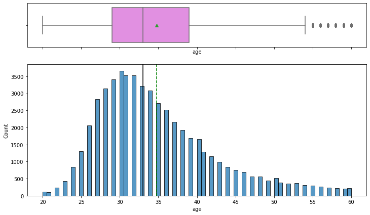

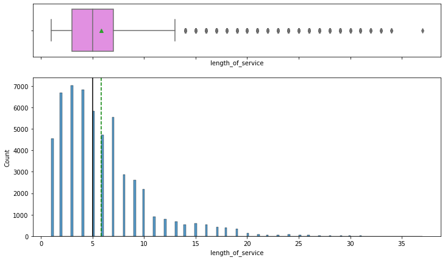

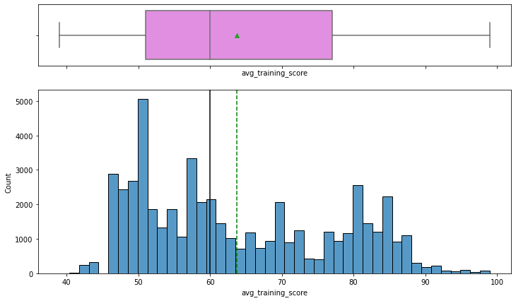

```python
def histogram_boxplot(data, feature, figsize=(12, 7), kde=False, bins=None):
    """
    Boxplot and histogram combined

    data: dataframe
    feature: dataframe column
    figsize: size of figure (default (12,7))
    kde: whether to show the density curve (default False)
    bins: number of bins for histogram (default None)
    """
    f2, (ax_box2, ax_hist2) = plt.subplots(
        nrows=2,  # Number of rows of the subplot grid= 2
        sharex=True,  # x-axis will be shared among all subplots
        gridspec_kw={"height_ratios": (0.25, 0.75)},
        figsize=figsize,
    )  # creating the 2 subplots
    sns.boxplot(
        data=data, x=feature, ax=ax_box2, showmeans=True, color="violet"
    )  # boxplot will be created and a star will indicate the mean value of the column
    sns.histplot(
        data=data, x=feature, kde=kde, ax=ax_hist2, bins=bins, palette="winter"
    ) if bins else sns.histplot(
        data=data, x=feature, kde=kde, ax=ax_hist2
    )  # For histogram
    ax_hist2.axvline(
        data[feature].mean(), color="green", linestyle="--"
    )  # Add mean to the histogram
    ax_hist2.axvline(
        data[feature].median(), color="black", linestyle="-"
    )  # Add median to the histogram


for column in continuous:
    histogram_boxplot(data, column)
```

**Function to create barplots that indicate percentage for each category**

```python
def labeled_barplot(data, feature, perc=False, n=None):
    """
    Barplot with percentage at the top

    data: dataframe
    feature: dataframe column
    perc: whether to display percentages instead of count (default is False)
    n: displays the top n category levels (default is None, i.e., display all levels)
    """

    total = len(data[feature])  # length of the column
    count = data[feature].nunique()
    if n is None:
        plt.figure(figsize=(count + 1, 5))
    else:
        plt.figure(figsize=(n + 1, 5))

    plt.xticks(rotation=90, fontsize=15)
    ax = sns.countplot(
        data=data,
        x=feature,
        palette="Paired",
        order=data[feature].value_counts().index[:n].sort_values(),
    )

    for p in ax.patches:
        if perc == True:
            label = "{:.1f}%".format(
                100 * p.get_height() / total
            )  # percentage of each class of the category
        else:
            label = p.get_height()  # count of each level of the category

        x = p.get_x() + p.get_width() / 2  # width of the plot
        y = p.get_height()  # height of the plot

        ax.annotate(
            label,
            (x, y),
            ha="center",
            va="center",
            size=12,
            xytext=(0, 5),
            textcoords="offset points",
        )  # annotate the percentage

    plt.show()  # show the plot
```

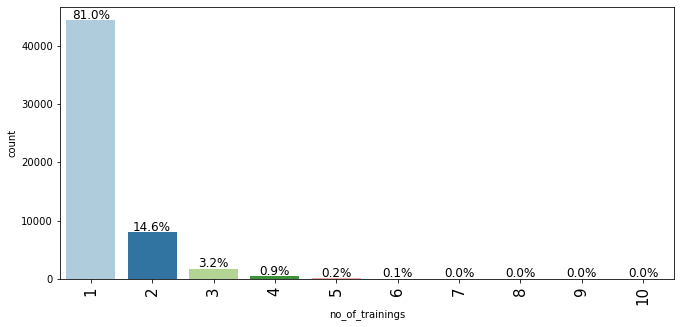

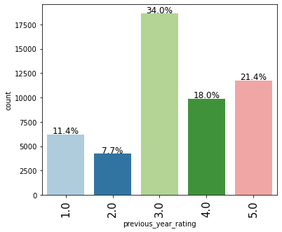

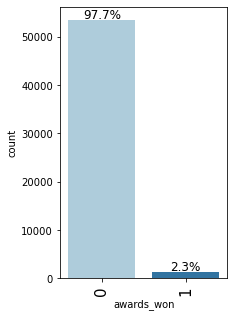

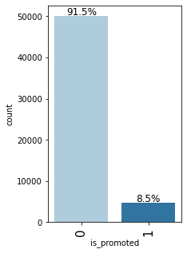

```python
for item in num_col:
    labeled_barplot(data, item, perc=True)
```

- only 8.5% of employees were promoted
- only 2.3 percent of employees have won an award.
- less than 20% of employees have recieved more than 1 training

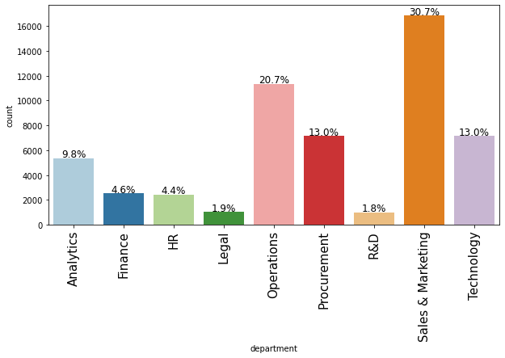

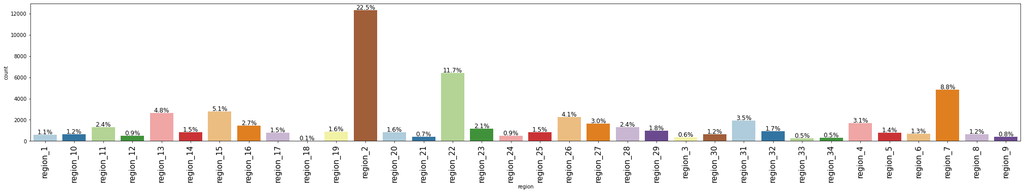

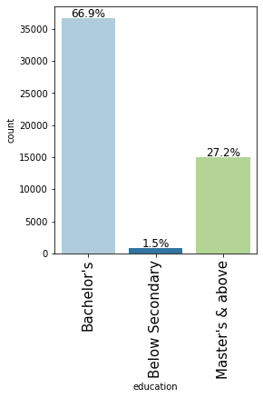

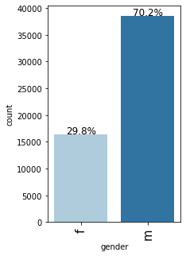

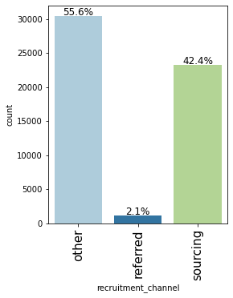

```python
for item in categorical:
    labeled_barplot(data, item, perc=True)
```

### Bivariate analysis

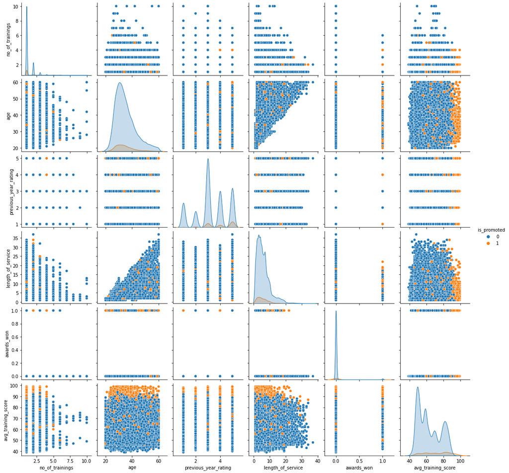

```python
sns.pairplot(data, hue="is_promoted")
```

## Creating Correlation Heatmap

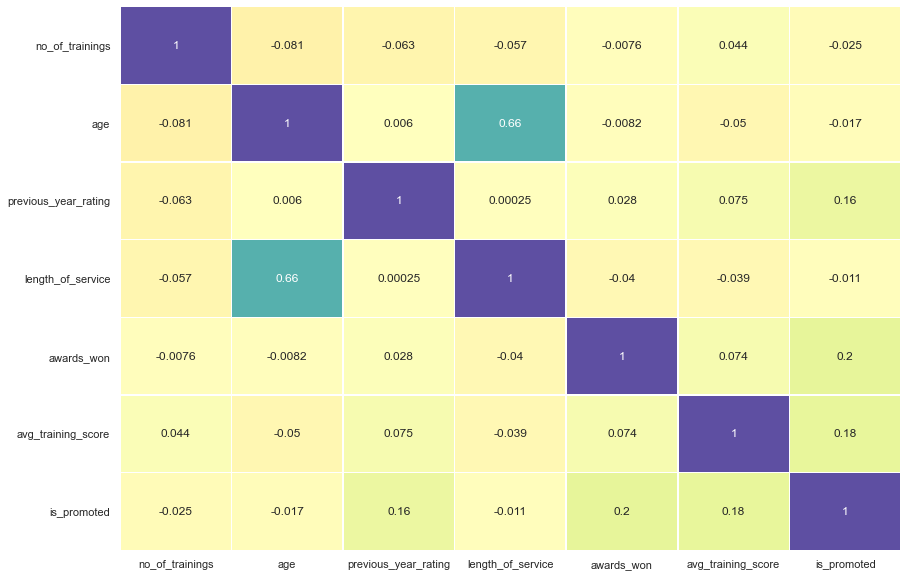

```python
sns.set(rc={"figure.figsize": (14, 10)})
sns.heatmap(
    data.corr(), annot=True, linewidths=0.5, center=0, cbar=False, cmap="Spectral"
)
plt.show()
```

- age and length_of_service have a high positive correlation among them, and both have a negative correlation with is_promoted and both have around 0.01 negative correlation with the Independent variable(is_promoted) and they will not be very helpful in our model so we can choose to drop one or both of them
- is_promoted seems to have a positive correlation with previous_year_rating, awards_won and avg_training_score

# Data Pre-Processing

```python
# replacing regions with fewer employees with "other"
data["region"] = np.where(
    data["region"].isin(["region_2", "region_22", "region_7"]), data["region"], "other"
)
```

```python
data.sample(10)
```

|  | department | region | education | gender | recruitment_channel | no_of_trainings | age | previous_year_rating | length_of_service | awards_won | avg_training_score | is_promoted |
| --- | --- | --- | --- | --- | --- | --- | --- | --- | --- | --- | --- | --- |
| 16374 | Technology | region_2 | Bachelor's | f | other | 1 | 41 | 3.000 | 4 | 0 | 77.000 | 0 |
| 17650 | Sales & Marketing | other | Master's & above | f | sourcing | 1 | 34 | 5.000 | 6 | 0 | 46.000 | 0 |
| 46824 | Sales & Marketing | region_2 | Master's & above | f | sourcing | 1 | 34 | 2.000 | 10 | 0 | 54.000 | 0 |
| 47294 | Procurement | other | Bachelor's | m | other | 1 | 41 | 4.000 | 13 | 0 | 70.000 | 0 |
| 1316 | Sales & Marketing | other | Master's & above | m | sourcing | 1 | 44 | 5.000 | 8 | 0 | 49.000 | 0 |
| 11187 | HR | region_22 | Master's & above | m | sourcing | 1 | 31 | 2.000 | 5 | 0 | 50.000 | 0 |
| 2003 | Operations | other | Bachelor's | m | other | 1 | 43 | 3.000 | 13 | 0 | NaN | 0 |
| 7412 | Operations | other | Master's & above | m | other | 1 | 50 | 3.000 | 21 | 0 | 60.000 | 0 |
| 40688 | Sales & Marketing | other | Bachelor's | m | other | 5 | 27 | 3.000 | 5 | 0 | 50.000 | 0 |
| 700 | Technology | other | Master's & above | f | other | 1 | 43 | 4.000 | 6 | 0 | 81.000 | 0 |

```python
# dropping columns with =0.011 correlation to our target value (is_promoted)
data.drop(["length_of_service"], axis=1, inplace=True)
```

```python
replaceStruct = {
    "gender": {"f": 1, "m": 2},
    "education": {"Bachelor's": 1, "Master's & above": 2, "Below Secondary": 3},
    "department": {
        "Sales & Marketing": 1,
        "Operations": 2,
        "Technology": 3,
        "Procurement": 4,
        "Analytics": 5,
        "Finance": 6,
        "HR": 7,
        "Legal": 8,
        "R&D": 9,
    },
    "region": {"region_2": 1, "region_22": 2, "region_7": 3, "other": 4},
    "recruitment_channel": {"sourcing": 1, "referred": 2, "other": 3},
}

data = data.replace(replaceStruct)
```

```python
df = data.copy()
sc = StandardScaler()
data_scaled = pd.DataFrame(sc.fit_transform(df), columns=df.columns)
```

### Data Preparation for Modeling

### Split data

```python
X = df.drop(["is_promoted"], axis=1)
y = data["is_promoted"]
```

```python
# Splitting data into training, validation and test sets:
# first we split data into 2 parts, say temporary and test

X_temp, X_test, y_temp, y_test = train_test_split(
    X, y, test_size=0.2, random_state=1, stratify=y
)

# then we split the temporary set into train and validation

X_train, X_val, y_train, y_val = train_test_split(
    X_temp, y_temp, test_size=0.25, random_state=1, stratify=y_temp
)
print(X_train.shape, X_val.shape, X_test.shape)
```

```
(32884, 10) (10962, 10) (10962, 10)
```

### Missing-Value Treatment

- We will use mode to impute missing values in education, previous_year_rating and avg_training_score column.

```python
# Let's impute the missing values
imp_mode = SimpleImputer(missing_values=np.nan, strategy="most_frequent")
cols_to_impute = ["education", "previous_year_rating", "avg_training_score"]

# fit and transform the imputer on train data
X_train[cols_to_impute] = imp_mode.fit_transform(X_train[cols_to_impute])

# Transform on validation and test data
X_val[cols_to_impute] = imp_mode.transform(X_val[cols_to_impute])

# fit and transform the imputer on test data
X_test[cols_to_impute] = imp_mode.transform(X_test[cols_to_impute])
```

```python
# Creating dummy variables for categorical variables
X_train = pd.get_dummies(data=X_train, drop_first=True)
X_val = pd.get_dummies(data=X_val, drop_first=True)
X_test = pd.get_dummies(data=X_test, drop_first=True)
```

### Model evaluation criterion

### Model can make wrong predictions as:

1. Could Give promotion to non-deserving employees - Loss of money
2. Not give promotion to deserving - Loss of talent (employees)

### Which case is more important?

- If we predict a person should be promoted when they shouldn't (False Positive), then company will be paying a higher salary than the talent that person is contributing, and higher ranking employees may not be as qualified as we would like.
- If we predict a person shouldn't be promoted when they should (False Negative), that person will loose interest in work and leave company and there will be a talent loss.
- In this case we care both about reducing number of False Positives and False Negatives

### How to reduce this loss?

- Precision and recall metric should be used

```python
models = []  # Empty list to store all the models

# Appending models into the list
models.append(("Bagging", BaggingClassifier(random_state=1)))
models.append(("Random forest", RandomForestClassifier(random_state=1)))
models.append(("GBM", GradientBoostingClassifier(random_state=1)))
models.append(("Adaboost", AdaBoostClassifier(random_state=1)))
models.append(("Xgboost", XGBClassifier(random_state=1, eval_metric="logloss")))
models.append(("dtree", DecisionTreeClassifier(random_state=1)))

results = []  # Empty list to store all model's CV scores
names = []  # Empty list to store name of the models
score = []
# loop through all models to get the mean cross validated score
print("\n" "Cross-Validation Performance:" "\n")
for name, model in models:
    scoring = "recall"
    kfold = StratifiedKFold(
        n_splits=5, shuffle=True, random_state=1
    )  # Setting number of splits equal to 5
    cv_result = cross_val_score(
        estimator=model, X=X_train, y=y_train, scoring=scoring, cv=kfold
    )
    results.append(cv_result)
    names.append(name)
    print("{}: {}".format(name, cv_result.mean()))

print("\n" "Validation Performance:" "\n")

for name, model in models:
    model.fit(X_train, y_train)
    scores = recall_score(y_val, model.predict(X_val))
    score.append(scores)
    print("{}: {}".format(name, scores))
```

```
Cross-Validation Performance:

Bagging: 0.3303571428571429
Random forest: 0.29250000000000004
GBM: 0.28714285714285714
Adaboost: 0.17285714285714288
Xgboost: 0.3296428571428572
dtree: 0.3703571428571429

Validation Performance:

Bagging: 0.3490364025695932
Random forest: 0.2826552462526767
GBM: 0.2944325481798715
Adaboost: 0.1734475374732334
Xgboost: 0.3297644539614561
dtree: 0.37366167023554603
```

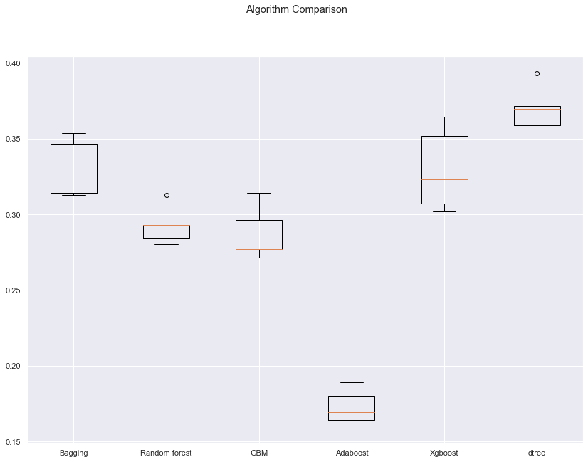

```python
# Plotting boxplots for CV scores of all models defined above
fig = plt.figure()

fig.suptitle("Algorithm Comparison")
ax = fig.add_subplot(111)

plt.boxplot(results)
ax.set_xticklabels(names)

plt.show()
```

# Oversampling and Undersampling the train data

## Oversampling train data using SMOTE

```python
# Fit SMOTE on train data(Synthetic Minority Oversampling Technique)
sm = SMOTE(sampling_strategy=0.4, k_neighbors=5, random_state=1)
X_train_over, y_train_over = sm.fit_resample(X_train, y_train)
```

```python
print("Before OverSampling, count of label '1': {}".format(sum(y_train == 1)))
print("Before OverSampling, count of label '0': {} \n".format(sum(y_train == 0)))

print("After OverSampling, count of label '1': {}".format(sum(y_train_over == 1)))
print("After OverSampling, count of label '0': {} \n".format(sum(y_train_over == 0)))

print("After OverSampling, the shape of train_X: {}".format(X_train_over.shape))
print("After OverSampling, the shape of train_y: {} \n".format(y_train_over.shape))
```

```
Before OverSampling, count of label '1': 2800
Before OverSampling, count of label '0': 30084

After OverSampling, count of label '1': 12033
After OverSampling, count of label '0': 30084

After OverSampling, the shape of train_X: (42117, 10)
After OverSampling, the shape of train_y: (42117,)
```

#### Let's train a decision tree classifier using the oversampled data

```python
dt1 = DecisionTreeClassifier(max_depth=5, random_state=1)

# training the decision tree model with oversampled training set
dt1.fit(X_train_over, y_train_over)
```

```
DecisionTreeClassifier(max_depth=5, random_state=1)
```

```python
# Predicting the target for train and validation set
pred_train = dt1.predict(X_train_over)
pred_val = dt1.predict(X_val)
```

#### We have trained the model, Let's check the performance on the oversampled train and validation sets

```python
# Checking f1 score on oversampled train and validation set
print(recall_score(y_train_over, pred_train))
print(recall_score(y_val, pred_val))
```

```
0.34322280395578825
0.16059957173447537
```

```python
# Checking Precision score on oversampled train and validation set
print(precision_score(y_train_over, pred_train))
print(precision_score(y_val, pred_val))
```

```
0.986857825567503
0.872093023255814
```

#### After checking the performance, let's look at the confusion matrices of the train and validation data

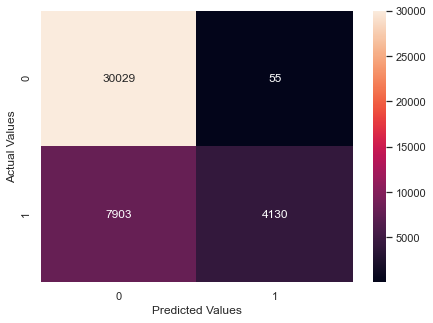

```python
# Confusion matrix for oversampled train data
cm = confusion_matrix(y_train_over, pred_train)
plt.figure(figsize=(7, 5))
sns.heatmap(cm, annot=True, fmt="g")
plt.xlabel("Predicted Values")
plt.ylabel("Actual Values")
```

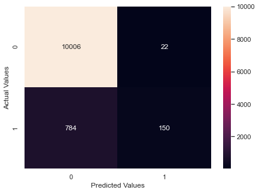

```python
# Confusion matrix for validation data
cm = confusion_matrix(y_val, pred_val)
plt.figure(figsize=(7, 5))
sns.heatmap(cm, annot=True, fmt="g")
plt.xlabel("Predicted Values")
plt.ylabel("Actual Values")
plt.show()
```

## Undersampling train data using Random Undersampler

```python
# fit random under sampler on the train data
rus = RandomUnderSampler(random_state=1, sampling_strategy=1)
X_train_un, y_train_un = rus.fit_resample(X_train, y_train)
```

```python
print("Before Under Sampling, count of label '1': {}".format(sum(y_train == 1)))
print("Before Under Sampling, count of label '0': {} \n".format(sum(y_train == 0)))

print("After Under Sampling, count of label '1': {}".format(sum(y_train_un == 1)))
print("After Under Sampling, count of label '0': {} \n".format(sum(y_train_un == 0)))

print("After Under Sampling, the shape of train_X: {}".format(X_train_un.shape))
print("After Under Sampling, the shape of train_y: {} \n".format(y_train_un.shape))
```

```
Before Under Sampling, count of label '1': 2800
Before Under Sampling, count of label '0': 30084

After Under Sampling, count of label '1': 2800
After Under Sampling, count of label '0': 2800

After Under Sampling, the shape of train_X: (5600, 10)
After Under Sampling, the shape of train_y: (5600,)
```

#### Let's train a decision tree classifier using the undersampled data

```python
dt2 = DecisionTreeClassifier(random_state=1, max_depth=4)

# training the decision tree model with oversampled training set
dt2.fit(X_train_un, y_train_un)
```

```
DecisionTreeClassifier(max_depth=4, random_state=1)
```

#### We have trained the model, let's check the performance on undersampled train and validation data

```python
# Predicting the target for train and validation set
pred_train = dt2.predict(X_train_un)
pred_val = dt2.predict(X_val)
```

```python
# Checking recall score on undersampled train and validation set
print(recall_score(y_train_un, pred_train))
print(recall_score(y_val, pred_val))
```

```
0.5407142857142857
0.5492505353319058
```

```python
# Checking precision score on undersampled train and validation set
print(precision_score(y_train_un, pred_train))
print(precision_score(y_val, pred_val))
```

```
0.715839243498818
0.19336600075386354
```

#### After checking the performance, let's look at the confusion matrices of the train and validation data

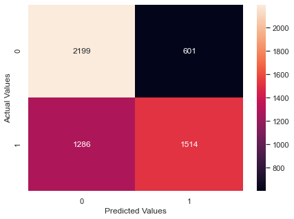

```python
# Confusion matrix for undersampled train data
cm = confusion_matrix(y_train_un, pred_train)
plt.figure(figsize=(7, 5))
sns.heatmap(cm, annot=True, fmt="g")
plt.xlabel("Predicted Values")
plt.ylabel("Actual Values")
plt.show()
```

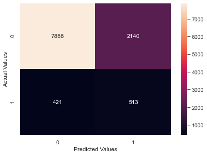

```python
# Confusion matrix for validation data
cm = confusion_matrix(y_val, pred_val)
plt.figure(figsize=(7, 5))
sns.heatmap(cm, annot=True, fmt="g")
plt.xlabel("Predicted Values")
plt.ylabel("Actual Values")
plt.show()
```

[output not shown]

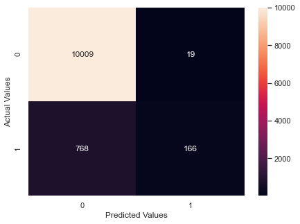

```python
# Now we have identified the best model, let's check its performance on test set
print(recall_score(y_test, dt1.predict(X_test)))

cm = confusion_matrix(y_test, dt1.predict(X_test))
plt.figure(figsize=(7, 5))
sns.heatmap(cm, annot=True, fmt="g")
plt.xlabel("Predicted Values")
plt.ylabel("Actual Values")
plt.show()
```

```python
print(precision_score(y_test, dt1.predict(X_test)))
```

```
0.8972972972972973
```

## XGboost

```python
xgb1 = XGBClassifier(random_state=1, eval_metric="logloss")

# training the decision tree model with oversampled training set
xgb1.fit(X_train_un, y_train_un)
```

```
XGBClassifier(base_score=0.5, booster='gbtree', colsample_bylevel=1,
              colsample_bynode=1, colsample_bytree=1, enable_categorical=False,
              eval_metric='logloss', gamma=0, gpu_id=-1, importance_type=None,
              interaction_constraints='', learning_rate=0.300000012,
              max_delta_step=0, max_depth=6, min_child_weight=1, missing=nan,
              monotone_constraints='()', n_estimators=100, n_jobs=8,
              num_parallel_tree=1, predictor='auto', random_state=1,
              reg_alpha=0, reg_lambda=1, scale_pos_weight=1, subsample=1,
              tree_method='exact', validate_parameters=1, verbosity=None)
```

```python
# Predicting the target for train and validation set
pred_train = xgb1.predict(X_train_over)
pred_val = xgb1.predict(X_val)
```

```python
# Checking recall score on undersampled train and validation set
print(recall_score(y_train_over, pred_train))
print(recall_score(y_val, pred_val))
```

```
0.7899941826643397
0.6434689507494646
```

```python
# Checking precision score on undersampled train and validation set
print(precision_score(y_train_over, pred_train))
print(precision_score(y_val, pred_val))
```

```
0.5869350456902939
0.20154258886653253
```

#### After checking the performance, let's look at the confusion matrices of the train and validation data

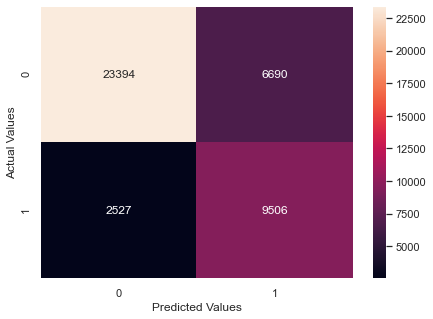

```python
# Confusion matrix for undersampled train data
cm = confusion_matrix(y_train_over, pred_train)
plt.figure(figsize=(7, 5))
sns.heatmap(cm, annot=True, fmt="g")
plt.xlabel("Predicted Values")
plt.ylabel("Actual Values")
plt.show()
```

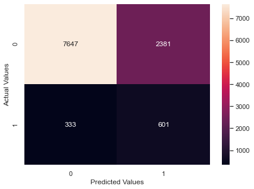

```python
# Confusion matrix for validation data
cm = confusion_matrix(y_val, pred_val)
plt.figure(figsize=(7, 5))
sns.heatmap(cm, annot=True, fmt="g")
plt.xlabel("Predicted Values")
plt.ylabel("Actual Values")
plt.show()
```

[output not shown]

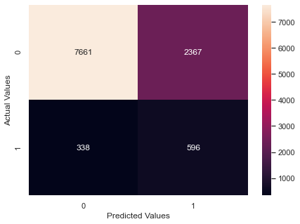

```python
# Now we have identified the best model, let's check its performance on test set
print(recall_score(y_test, xgb1.predict(X_test)))

cm = confusion_matrix(y_test, xgb1.predict(X_test))
plt.figure(figsize=(7, 5))
sns.heatmap(cm, annot=True, fmt="g")
plt.xlabel("Predicted Values")
plt.ylabel("Actual Values")
plt.show()
```

```python
print(precision_score(y_test, dt1.predict(X_test)))
```

```
0.8972972972972973
```

# Hyperparameter Tuning

**First let's create two functions to calculate different metrics and confusion matrix, so that we don't have to use the same code repeatedly for each model.**

```python
# defining a function to compute different metrics to check performance of a classification model built using sklearn
def model_performance_classification_sklearn(model, predictors, target):
    """
    Function to compute different metrics to check classification model performance

    model: classifier
    predictors: independent variables
    target: dependent variable
    """

    # predicting using the independent variables
    pred = model.predict(predictors)

    acc = accuracy_score(target, pred)  # to compute Accuracy
    recall = recall_score(target, pred)  # to compute Recall
    precision = precision_score(target, pred)  # to compute Precision
    f1 = f1_score(target, pred)  # to compute F1-score

    # creating a dataframe of metrics
    df_perf = pd.DataFrame(
        {"Accuracy": acc, "Recall": recall, "Precision": precision, "F1": f1,},
        index=[0],
    )

    return df_perf
```

```python
def confusion_matrix_sklearn(model, predictors, target):
    """
    To plot the confusion_matrix with percentages

    model: classifier
    predictors: independent variables
    target: dependent variable
    """
    y_pred = model.predict(predictors)
    cm = confusion_matrix(target, y_pred)
    labels = np.asarray(
        [
            ["{0:0.0f}".format(item) + "\n{0:.2%}".format(item / cm.flatten().sum())]
            for item in cm.flatten()
        ]
    ).reshape(2, 2)

    plt.figure(figsize=(6, 4))
    sns.heatmap(cm, annot=labels, fmt="")
    plt.ylabel("True label")
    plt.xlabel("Predicted label")
```

### GridSearchCV

```python
%%time

#defining model
model = XGBClassifier(random_state=1,eval_metric='logloss')

#Parameter grid to pass in GridSearchCV
param_grid={'n_estimators':np.arange(50,150,50),
            'scale_pos_weight':[2,5,10],
            'learning_rate':[0.01,0.2],
            'gamma':[0,1,3],
            'subsample':[0.8,1],
            'max_depth':np.arange(1,5,1),
            'reg_lambda':[5,10]}


# Type of scoring used to compare parameter combinations
scorer = metrics.make_scorer(metrics.precision_score)

#Calling GridSearchCV
grid_cv = GridSearchCV(estimator=model, param_grid=param_grid, scoring=scorer, cv=5, n_jobs = -1, verbose= 2)

#Fitting parameters in GridSearchCV
grid_cv.fit(X_train_over,y_train_over)


print("Best parameters are {} with CV score={}:" .format(grid_cv.best_params_,grid_cv.best_score_))
```

```
Fitting 5 folds for each of 576 candidates, totalling 2880 fits
Best parameters are {'gamma': 0, 'learning_rate': 0.2, 'max_depth': 4, 'n_estimators': 100, 'reg_lambda': 5, 'scale_pos_weight': 2, 'subsample': 1} with CV score=0.8890077736612267:
CPU times: user 16.6 s, sys: 2.76 s, total: 19.4 s
Wall time: 14min 20s
```

```python
# building model with best parameters
xgb_tuned1 = XGBClassifier(
    random_state=1,
    n_estimators=100,
    scale_pos_weight=2,
    subsample=1,
    learning_rate=0.2,
    gamma=0,
    eval_metric="logloss",
    reg_lambda=5,
    max_depth=4,
)

# Fit the model on training data
xgb_tuned1.fit(X_train_over, y_train_over)
```

```
XGBClassifier(base_score=0.5, booster='gbtree', colsample_bylevel=1,
              colsample_bynode=1, colsample_bytree=1, enable_categorical=False,
              eval_metric='logloss', gamma=0, gpu_id=-1, importance_type=None,
              interaction_constraints='', learning_rate=0.2, max_delta_step=0,
              max_depth=4, min_child_weight=1, missing=nan,
              monotone_constraints='()', n_estimators=100, n_jobs=8,
              num_parallel_tree=1, predictor='auto', random_state=1,
              reg_alpha=0, reg_lambda=5, scale_pos_weight=2, subsample=1,
              tree_method='exact', validate_parameters=1, verbosity=None)
```

```python
# Calculating different metrics on train set
xgboost_grid_train = model_performance_classification_sklearn(
    xgb_tuned1, X_train_over, y_train_over
)
print("Training performance:")
xgboost_grid_train
```

```
Training performance:
```

|  | Accuracy | Recall | Precision | F1 |
| --- | --- | --- | --- | --- |
| 0 | 0.914 | 0.789 | 0.897 | 0.840 |

```python
# Calculating different metrics on validation set
xgboost_grid_val = model_performance_classification_sklearn(xgb_tuned1, X_val, y_val)
print("Validation performance:")
xgboost_grid_val
```

```
Validation performance:
```

|  | Accuracy | Recall | Precision | F1 |
| --- | --- | --- | --- | --- |
| 0 | 0.917 | 0.426 | 0.514 | 0.466 |

[figure not shown]

```python
# creating confusion matrix
confusion_matrix_sklearn(xgb_tuned1, X_val, y_val)
```

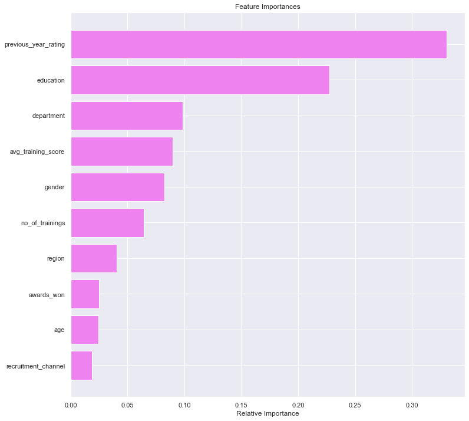

```python
feature_names = X.columns
importances = xgb_tuned1.feature_importances_
indices = np.argsort(importances)

plt.figure(figsize=(12, 12))
plt.title("Feature Importances")
plt.barh(range(len(indices)), importances[indices], color="violet", align="center")
plt.yticks(range(len(indices)), [feature_names[i] for i in indices])
plt.xlabel("Relative Importance")
plt.show()
```

## Pipelines for productionizing the model

- Now, we have a final model. let's use pipelines to put the model into production

## Column Transformer

- We will create 2 different pipelines, one for numerical columns and one for categorical columns
- For numerical columns, we will do missing value imputation as pre-processing
- For categorical columns, we will do one hot encoding and missing value imputation as pre-processing
- We are doing missing value imputation for the whole data, so that if there is any missing value in the data in future that can be taken care of.

```python
# creating a list of numerical variables
numerical_features = num_col = [
    "no_of_trainings",
    "previous_year_rating",
    "awards_won",
    "age",
    "avg_training_score",
]

# creating a transformer for numerical variables, which will apply simple imputer on the numerical variables
numeric_transformer = Pipeline(steps=[("imputer", SimpleImputer(strategy="median"))])

# creating a list of categorical variables
categorical_features = categorical

# creating a transformer for categorical variables, which will first apply simple imputer and
# then do one hot encoding for categorical variables
categorical_transformer = Pipeline(
    steps=[
        ("imputer", SimpleImputer(strategy="most_frequent")),
        ("onehot", OneHotEncoder(handle_unknown="ignore")),
    ]
)

# handle_unknown = "ignore", allows model to handle any unknown category in the test data

# combining categorical transformer and numerical transformer using a column transformer

preprocessor = ColumnTransformer(
    transformers=[
        ("num", numeric_transformer, numerical_features),
        ("cat", categorical_transformer, categorical_features),
    ],
    remainder="passthrough",
)
# remainder = "passthrough" has been used, it will allow variables that are present in original data
# but not in "numerical_columns" and "categorical_columns" to pass through the column transformer without any changes
```

```python
X = df.drop("is_promoted", axis=1)
y = data["is_promoted"]
```

- Now we already know the best model we need to process with, so we don't need to divide data into 3 parts

```python
# Splitting the data into train and test sets
X_train, X_test, y_train, y_test = train_test_split(
    X, Y, test_size=0.30, random_state=1, stratify=Y
)
print(X_train.shape, X_test.shape)
```

```
(38365, 10) (16443, 10)
```

```python
# Creating new pipeline with best parameters
model = Pipeline(
    steps=[
        ("pre", preprocessor),
        (
            "XGB",
            XGBClassifier(
                random_state=1,
                n_estimators=100,
                scale_pos_weight=2,
                subsample=1,
                learning_rate=0.2,
                gamma=0,
                eval_metric="logloss",
                reg_lambda=5,
                max_depth=4,
            ),
        ),
    ]
)
# Fit the model on training data
model.fit(X_train, y_train)
```

```
Pipeline(steps=[('pre',
                 ColumnTransformer(remainder='passthrough',
                                   transformers=[('num',
                                                  Pipeline(steps=[('imputer',
                                                                   SimpleImputer(strategy='median'))]),
                                                  ['no_of_trainings',
                                                   'previous_year_rating',
                                                   'awards_won', 'age',
                                                   'avg_training_score']),
                                                 ('cat',
                                                  Pipeline(steps=[('imputer',
                                                                   SimpleImputer(strategy='most_frequent')),
                                                                  ('onehot',
                                                                   OneHotEncoder(handle_unknown='ig...
                               eval_metric='logloss', gamma=0, gpu_id=-1,
                               importance_type=None, interaction_constraints='',
                               learning_rate=0.2, max_delta_step=0, max_depth=4,
                               min_child_weight=1, missing=nan,
                               monotone_constraints='()', n_estimators=100,
                               n_jobs=8, num_parallel_tree=1, predictor='auto',
                               random_state=1, reg_alpha=0, reg_lambda=5,
                               scale_pos_weight=2, subsample=1,
                               tree_method='exact', validate_parameters=1,
                               verbosity=None))])
```